# HR Attrition project - Juan Diego

This project will explain possible causes of why employees inside a company decide to quit their job.

```python
import pip
import pandas as pd
import numpy as np
import seaborn as sns
import matplotlib.pyplot as plt
```

```python
Hrattr = 'HR attrition.csv'
df = pd.read_csv(Hrattr)
df
```

|  | Age | Attrition | BusinessTravel | DailyRate | Department | DistanceFromHome | Education | EducationField | EmployeeCount | EmployeeNumber | ... | RelationshipSatisfaction | StandardHours | StockOptionLevel | TotalWorkingYears | TrainingTimesLastYear | WorkLifeBalance | YearsAtCompany | YearsInCurrentRole | YearsSinceLastPromotion | YearsWithCurrManager |
| --- | --- | --- | --- | --- | --- | --- | --- | --- | --- | --- | --- | --- | --- | --- | --- | --- | --- | --- | --- | --- | --- |
| 0 | 41 | Yes | Travel_Rarely | 1102 | Sales | 1 | 2 | Life Sciences | 1 | 1 | ... | 1 | 80 | 0 | 8 | 0 | 1 | 6 | 4 | 0 | 5 |
| 1 | 49 | No | Travel_Frequently | 279 | Research & Development | 8 | 1 | Life Sciences | 1 | 2 | ... | 4 | 80 | 1 | 10 | 3 | 3 | 10 | 7 | 1 | 7 |
| 2 | 37 | Yes | Travel_Rarely | 1373 | Research & Development | 2 | 2 | Other | 1 | 4 | ... | 2 | 80 | 0 | 7 | 3 | 3 | 0 | 0 | 0 | 0 |
| 3 | 33 | No | Travel_Frequently | 1392 | Research & Development | 3 | 4 | Life Sciences | 1 | 5 | ... | 3 | 80 | 0 | 8 | 3 | 3 | 8 | 7 | 3 | 0 |
| 4 | 27 | No | Travel_Rarely | 591 | Research & Development | 2 | 1 | Medical | 1 | 7 | ... | 4 | 80 | 1 | 6 | 3 | 3 | 2 | 2 | 2 | 2 |
| ... | ... | ... | ... | ... | ... | ... | ... | ... | ... | ... | ... | ... | ... | ... | ... | ... | ... | ... | ... | ... | ... |
| 1465 | 36 | No | Travel_Frequently | 884 | Research & Development | 23 | 2 | Medical | 1 | 2061 | ... | 3 | 80 | 1 | 17 | 3 | 3 | 5 | 2 | 0 | 3 |
| 1466 | 39 | No | Travel_Rarely | 613 | Research & Development | 6 | 1 | Medical | 1 | 2062 | ... | 1 | 80 | 1 | 9 | 5 | 3 | 7 | 7 | 1 | 7 |
| 1467 | 27 | No | Travel_Rarely | 155 | Research & Development | 4 | 3 | Life Sciences | 1 | 2064 | ... | 2 | 80 | 1 | 6 | 0 | 3 | 6 | 2 | 0 | 3 |
| 1468 | 49 | No | Travel_Frequently | 1023 | Sales | 2 | 3 | Medical | 1 | 2065 | ... | 4 | 80 | 0 | 17 | 3 | 2 | 9 | 6 | 0 | 8 |
| 1469 | 34 | No | Travel_Rarely | 628 | Research & Development | 8 | 3 | Medical | 1 | 2068 | ... | 1 | 80 | 0 | 6 | 3 | 4 | 4 | 3 | 1 | 2 |

1470 rows × 35 columns

```python
df.shape
```

```
(1470, 35)
```

```python
df.columns
```

[output not shown]

```python
df.dtypes
```

```
Age                          int64
Attrition                   object
BusinessTravel              object
DailyRate                    int64
Department                  object
DistanceFromHome             int64
Education                    int64
EducationField              object
EmployeeCount                int64
EmployeeNumber               int64
EnvironmentSatisfaction      int64
Gender                      object
HourlyRate                   int64
JobInvolvement               int64
JobLevel                     int64
JobRole                     object
JobSatisfaction              int64
MaritalStatus               object
MonthlyIncome                int64
MonthlyRate                  int64
NumCompaniesWorked           int64
Over18                      object
OverTime                    object
PercentSalaryHike            int64
PerformanceRating            int64
RelationshipSatisfaction     int64
StandardHours                int64
StockOptionLevel             int64
TotalWorkingYears            int64
TrainingTimesLastYear        int64
WorkLifeBalance              int64
YearsAtCompany               int64
YearsInCurrentRole           int64
YearsSinceLastPromotion      int64
YearsWithCurrManager         int64
dtype: object
```

```python
df.isnull().sum()
```

```
Age                         0
Attrition                   0
BusinessTravel              0
DailyRate                   0
Department                  0
DistanceFromHome            0
Education                   0
EducationField              0
EmployeeCount               0
EmployeeNumber              0
EnvironmentSatisfaction     0
Gender                      0
HourlyRate                  0
JobInvolvement              0
JobLevel                    0
JobRole                     0
JobSatisfaction             0
MaritalStatus               0
MonthlyIncome               0
MonthlyRate                 0
NumCompaniesWorked          0
Over18                      0
OverTime                    0
PercentSalaryHike           0
PerformanceRating           0
RelationshipSatisfaction    0
StandardHours               0
StockOptionLevel            0
TotalWorkingYears           0
TrainingTimesLastYear       0
WorkLifeBalance             0
YearsAtCompany              0
YearsInCurrentRole          0
YearsSinceLastPromotion     0
YearsWithCurrManager        0
dtype: int64
```

```python
statistics = df.describe()
print(statistics)
```

```
               Age    DailyRate  DistanceFromHome    Education  EmployeeCount  \
count  1470.000000  1470.000000       1470.000000  1470.000000         1470.0
mean     36.923810   802.485714          9.192517     2.912925            1.0
std       9.135373   403.509100          8.106864     1.024165            0.0
min      18.000000   102.000000          1.000000     1.000000            1.0
25%      30.000000   465.000000          2.000000     2.000000            1.0
50%      36.000000   802.000000          7.000000     3.000000            1.0
75%      43.000000  1157.000000         14.000000     4.000000            1.0
max      60.000000  1499.000000         29.000000     5.000000            1.0

       EmployeeNumber  EnvironmentSatisfaction   HourlyRate  JobInvolvement  \
count     1470.000000              1470.000000  1470.000000     1470.000000
mean      1024.865306                 2.721769    65.891156        2.729932
std        602.024335                 1.093082    20.329428        0.711561
min          1.000000                 1.000000    30.000000        1.000000
25%        491.250000                 2.000000    48.000000        2.000000
50%       1020.500000                 3.000000    66.000000        3.000000
75%       1555.750000                 4.000000    83.750000        3.000000
max       2068.000000                 4.000000   100.000000        4.000000

          JobLevel  ...  PerformanceRating  RelationshipSatisfaction  \
count  1470.000000  ...        1470.000000               1470.000000
mean      2.063946  ...           3.153741                  2.712245
std       1.106940  ...           0.360824                  1.081209
min       1.000000  ...           3.000000                  1.000000
25%       1.000000  ...           3.000000                  2.000000
50%       2.000000  ...           3.000000                  3.000000
75%       3.000000  ...           3.000000                  4.000000
max       5.000000  ...           4.000000                  4.000000

       StockOptionLevel  TotalWorkingYears  TrainingTimesLastYear  \
count       1470.000000        1470.000000            1470.000000
mean           0.793878          11.279592               2.799320
std            0.852077           7.780782               1.289271
min            0.000000           0.000000               0.000000
25%            0.000000           6.000000               2.000000
50%            1.000000          10.000000               3.000000
75%            1.000000          15.000000               3.000000
max            3.000000          40.000000               6.000000

       WorkLifeBalance  YearsAtCompany  YearsInCurrentRole  \
count      1470.000000     1470.000000         1470.000000
mean          2.761224        7.008163            4.229252
std           0.706476        6.126525            3.623137
min           1.000000        0.000000            0.000000
25%           2.000000        3.000000            2.000000
50%           3.000000        5.000000            3.000000
75%           3.000000        9.000000            7.000000
max           4.000000       40.000000           18.000000

       YearsSinceLastPromotion  YearsWithCurrManager
count              1470.000000           1470.000000
mean                  2.187755              4.123129
std                   3.222430              3.568136
min                   0.000000              0.000000
25%                   0.000000              2.000000
50%                   1.000000              3.000000
75%                   3.000000              7.000000
max                  15.000000             17.000000

[8 rows x 25 columns]
```

```python
Dropcolumn ='Over18'
Dropcolumn ='DailyRate'
Dropcolumn ='HourlyRate'
Dropcolumn ='EmployeeCount'
Dropcolumn ='StandardHours'
df = df.drop(Dropcolumn,axis=1)
```

```python
df
```

[output not shown]

```python
df
```

|  | Age | Attrition | BusinessTravel | DailyRate | Department | DistanceFromHome | Education | EducationField | EmployeeCount | EmployeeNumber | ... | PerformanceRating | RelationshipSatisfaction | StockOptionLevel | TotalWorkingYears | TrainingTimesLastYear | WorkLifeBalance | YearsAtCompany | YearsInCurrentRole | YearsSinceLastPromotion | YearsWithCurrManager |
| --- | --- | --- | --- | --- | --- | --- | --- | --- | --- | --- | --- | --- | --- | --- | --- | --- | --- | --- | --- | --- | --- |
| 0 | 41 | Yes | Travel_Rarely | 1102 | Sales | 1 | 2 | Life Sciences | 1 | 1 | ... | 3 | 1 | 0 | 8 | 0 | 1 | 6 | 4 | 0 | 5 |
| 1 | 49 | No | Travel_Frequently | 279 | Research & Development | 8 | 1 | Life Sciences | 1 | 2 | ... | 4 | 4 | 1 | 10 | 3 | 3 | 10 | 7 | 1 | 7 |
| 2 | 37 | Yes | Travel_Rarely | 1373 | Research & Development | 2 | 2 | Other | 1 | 4 | ... | 3 | 2 | 0 | 7 | 3 | 3 | 0 | 0 | 0 | 0 |
| 3 | 33 | No | Travel_Frequently | 1392 | Research & Development | 3 | 4 | Life Sciences | 1 | 5 | ... | 3 | 3 | 0 | 8 | 3 | 3 | 8 | 7 | 3 | 0 |
| 4 | 27 | No | Travel_Rarely | 591 | Research & Development | 2 | 1 | Medical | 1 | 7 | ... | 3 | 4 | 1 | 6 | 3 | 3 | 2 | 2 | 2 | 2 |
| ... | ... | ... | ... | ... | ... | ... | ... | ... | ... | ... | ... | ... | ... | ... | ... | ... | ... | ... | ... | ... | ... |
| 1465 | 36 | No | Travel_Frequently | 884 | Research & Development | 23 | 2 | Medical | 1 | 2061 | ... | 3 | 3 | 1 | 17 | 3 | 3 | 5 | 2 | 0 | 3 |
| 1466 | 39 | No | Travel_Rarely | 613 | Research & Development | 6 | 1 | Medical | 1 | 2062 | ... | 3 | 1 | 1 | 9 | 5 | 3 | 7 | 7 | 1 | 7 |
| 1467 | 27 | No | Travel_Rarely | 155 | Research & Development | 4 | 3 | Life Sciences | 1 | 2064 | ... | 4 | 2 | 1 | 6 | 0 | 3 | 6 | 2 | 0 | 3 |
| 1468 | 49 | No | Travel_Frequently | 1023 | Sales | 2 | 3 | Medical | 1 | 2065 | ... | 3 | 4 | 0 | 17 | 3 | 2 | 9 | 6 | 0 | 8 |
| 1469 | 34 | No | Travel_Rarely | 628 | Research & Development | 8 | 3 | Medical | 1 | 2068 | ... | 3 | 1 | 0 | 6 | 3 | 4 | 4 | 3 | 1 | 2 |

1470 rows × 34 columns

# Correlation and possible explanations

We are going to create a correlation matrix in order to find possible patterns of what is most valuable in the company.

[figure not shown]

```python
sns.heatmap(df.corr().round(2))
```

Then, we proceed to create another column by categorizing the ages into 3 group ages

```python
def Age_range(Age):

    if Age >= 18 and Age <= 35:
        return '18 to 35'
    elif Age > 35 and Age <= 50:
        return '35 to 50'
    elif Age > 50:
        return '50 or more'
    else:
        return 'Unknown'

dfAttrition['AgeGroup'] = dfAttrition['Age'].apply(Age_range)
dfAttrition
```

|  | Age | Attrition | BusinessTravel | DailyRate | Department | DistanceFromHome | Education | EducationField | EmployeeCount | EmployeeNumber | ... | RelationshipSatisfaction | StockOptionLevel | TotalWorkingYears | TrainingTimesLastYear | WorkLifeBalance | YearsAtCompany | YearsInCurrentRole | YearsSinceLastPromotion | YearsWithCurrManager | AgeGroup |
| --- | --- | --- | --- | --- | --- | --- | --- | --- | --- | --- | --- | --- | --- | --- | --- | --- | --- | --- | --- | --- | --- |
| 0 | 41 | Yes | Travel_Rarely | 1102 | Sales | 1 | 2 | Life Sciences | 1 | 1 | ... | 1 | 0 | 8 | 0 | 1 | 6 | 4 | 0 | 5 | 35 to 50 |
| 2 | 37 | Yes | Travel_Rarely | 1373 | Research & Development | 2 | 2 | Other | 1 | 4 | ... | 2 | 0 | 7 | 3 | 3 | 0 | 0 | 0 | 0 | 35 to 50 |
| 14 | 28 | Yes | Travel_Rarely | 103 | Research & Development | 24 | 3 | Life Sciences | 1 | 19 | ... | 2 | 0 | 6 | 4 | 3 | 4 | 2 | 0 | 3 | 18 to 35 |
| 21 | 36 | Yes | Travel_Rarely | 1218 | Sales | 9 | 4 | Life Sciences | 1 | 27 | ... | 2 | 0 | 10 | 4 | 3 | 5 | 3 | 0 | 3 | 35 to 50 |
| 24 | 34 | Yes | Travel_Rarely | 699 | Research & Development | 6 | 1 | Medical | 1 | 31 | ... | 3 | 0 | 8 | 2 | 3 | 4 | 2 | 1 | 3 | 18 to 35 |
| ... | ... | ... | ... | ... | ... | ... | ... | ... | ... | ... | ... | ... | ... | ... | ... | ... | ... | ... | ... | ... | ... |
| 1438 | 23 | Yes | Travel_Frequently | 638 | Sales | 9 | 3 | Marketing | 1 | 2023 | ... | 1 | 1 | 1 | 3 | 2 | 1 | 0 | 1 | 0 | 18 to 35 |
| 1442 | 29 | Yes | Travel_Rarely | 1092 | Research & Development | 1 | 4 | Medical | 1 | 2027 | ... | 2 | 3 | 4 | 3 | 4 | 2 | 2 | 2 | 2 | 18 to 35 |
| 1444 | 56 | Yes | Travel_Rarely | 310 | Research & Development | 7 | 2 | Technical Degree | 1 | 2032 | ... | 4 | 1 | 14 | 4 | 1 | 10 | 9 | 9 | 8 | 50 or more |
| 1452 | 50 | Yes | Travel_Frequently | 878 | Sales | 1 | 4 | Life Sciences | 1 | 2044 | ... | 4 | 2 | 12 | 3 | 3 | 6 | 3 | 0 | 1 | 35 to 50 |
| 1461 | 50 | Yes | Travel_Rarely | 410 | Sales | 28 | 3 | Marketing | 1 | 2055 | ... | 2 | 1 | 20 | 3 | 3 | 3 | 2 | 2 | 0 | 35 to 50 |

237 rows × 35 columns

Histogram showing the attrition by age group

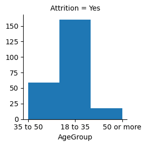

```python
agehist = sns.FacetGrid(dfAttrition, col='Attrition')
agehist.map(plt.hist, 'AgeGroup', bins=3)
```

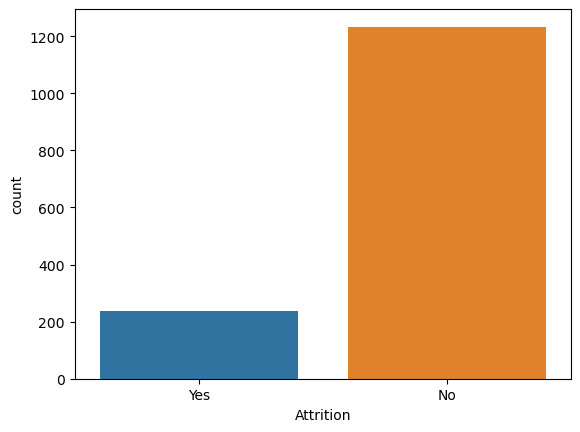

```python
sns.countplot(x = "Attrition", data = df)
```

```python
(df.groupby('Attrition').Attrition.count() / df['Attrition'].count()) *100
```

```
Attrition
No     83.877551
Yes    16.122449
Name: Attrition, dtype: float64
```

We can see that there is an Attrition of **16.12%** among all Employees.

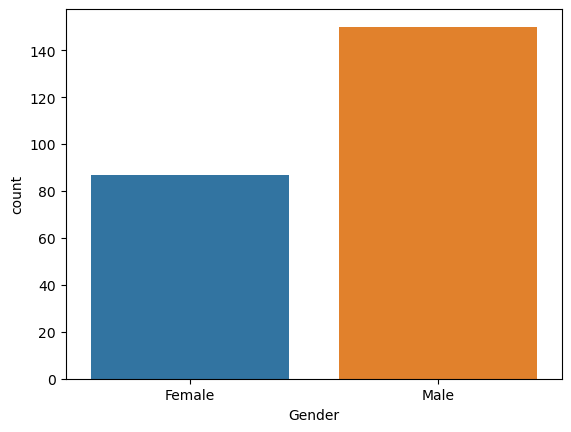

```python
dfAttrition = df[df["Attrition"] == "Yes"]
dfNoAttrition = df[df["Attrition"] == "No"]
sns.countplot(x = "Gender", data = dfAttrition)
```

```python
pd.crosstab([dfAttrition["Department"], dfAttrition["Gender"]], dfAttrition["JobSatisfaction"],
    margins = True).style.background_gradient(cmap = "summer_r")
```

| Department | JobSatisfaction Gender | 1 | 2 | 3 | 4 | All |
| --- | --- | --- | --- | --- | --- | --- |
| Human Resources | Female | 1 | 2 | 2 | 1 | 6 |
|  | Male | 4 | 0 | 1 | 1 | 6 |
| Research & Development | Female | 13 | 11 | 11 | 8 | 43 |
|  | Male | 25 | 13 | 32 | 20 | 90 |
| Sales | Female | 7 | 11 | 13 | 7 | 38 |
|  | Male | 16 | 9 | 14 | 15 | 54 |
| All |  | 66 | 46 | 73 | 52 | 237 |

We can clearly see low satisfaction jobs within the categories. Research and Development department has critical negative ratings and is increasing considerably the attritions metric. Human resources apparently is doing good and Sales can do better also. From this finding we are going to give a further look to R&D

```python
pd.crosstab([dfAttrition["Department"], dfAttrition["Gender"]], dfAttrition["OverTime"],
    margins = True).style.background_gradient(cmap = "summer_r")
```

| Department | OverTime Gender | No | Yes | All |
| --- | --- | --- | --- | --- |
| Human Resources | Female | 3 | 3 | 6 |
|  | Male | 4 | 2 | 6 |
| Research & Development | Female | 19 | 24 | 43 |
|  | Male | 40 | 50 | 90 |
| Sales | Female | 18 | 20 | 38 |
|  | Male | 26 | 28 | 54 |
| All |  | 110 | 127 | 237 |

```python
pd.crosstab([dfAttrition["Department"], dfAttrition["Gender"]], dfAttrition["WorkLifeBalance"],
    margins = True).style.background_gradient(cmap = "summer_r")
```

| Department | WorkLifeBalance Gender | 1 | 2 | 3 | 4 | All |
| --- | --- | --- | --- | --- | --- | --- |
| Human Resources | Female | 0 | 2 | 4 | 0 | 6 |
|  | Male | 0 | 0 | 5 | 1 | 6 |
| Research & Development | Female | 4 | 7 | 24 | 8 | 43 |
|  | Male | 15 | 25 | 44 | 6 | 90 |
| Sales | Female | 3 | 10 | 19 | 6 | 38 |
|  | Male | 3 | 14 | 31 | 6 | 54 |
| All |  | 25 | 58 | 127 | 27 | 237 |

Also, the percentage of employees quiting tend to have worked less than 5 years in the company. This means that most of the attritions that are explained by Junior - Mid Seniors professionals in which their desires are not fulfilled and want to try new experiences

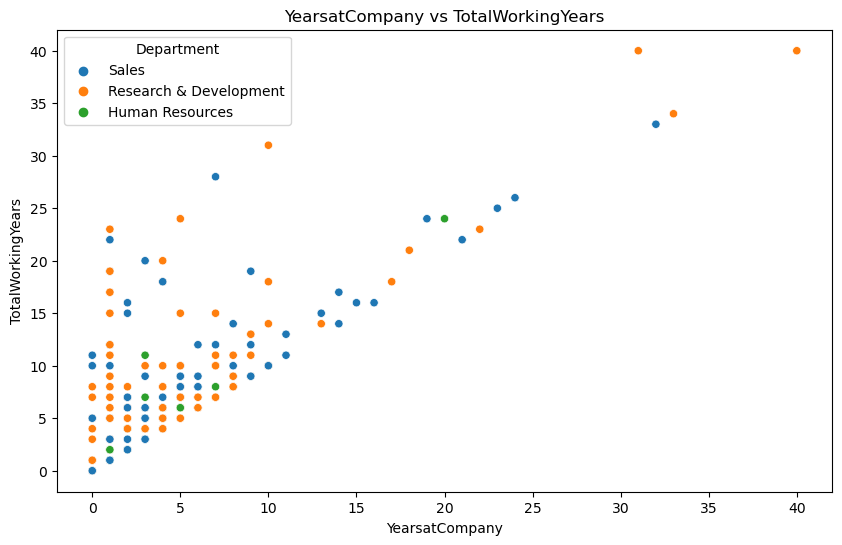

```python
plt.figure(figsize=(10, 6))
sns.scatterplot(x='YearsAtCompany', y='TotalWorkingYears', data=dfAttrition, hue='Department')
plt.title('YearsatCompany vs TotalWorkingYears')
plt.xlabel('YearsatCompany')
plt.ylabel('TotalWorkingYears')
plt.legend(title='Department')
plt.show()
```